# Students_Performace_in_Exames_pt

## Performace de estudantes em exames

Análise de um conjunto de dados de estudantes em alguns teste.

### Objetivo

Entender se alguns fatores influênciam na performace dos alunos, esse fotores são socioeconômicos ou preparatórios.

### Imports

```python
import pandas as pd
import numpy as np
import seaborn as sns
import matplotlib.pyplot as plt
```

### Carregando os dados

Fontes dos dados: https://www.kaggle.com/spscientist/students-performance-in-exams

```python
df = pd.read_csv('StudentsPerformance.csv')
```

Primeira vizualização dos dados.

```python
df.head()
```

|  | gender | race/ethnicity | parental level of education | lunch | test preparation course | math score | reading score | writing score |
| --- | --- | --- | --- | --- | --- | --- | --- | --- |
| 0 | female | group B | bachelor's degree | standard | none | 72 | 72 | 74 |
| 1 | female | group C | some college | standard | completed | 69 | 90 | 88 |
| 2 | female | group B | master's degree | standard | none | 90 | 95 | 93 |
| 3 | male | group A | associate's degree | free/reduced | none | 47 | 57 | 44 |
| 4 | male | group C | some college | standard | none | 76 | 78 | 75 |

### Avaliando os dados

Informação dos tipos de dados.

```python
df.info(0)
```

```
<class 'pandas.core.frame.DataFrame'>
RangeIndex: 1000 entries, 0 to 999
Data columns (total 8 columns):
gender                         1000 non-null object
race/ethnicity                 1000 non-null object
parental level of education    1000 non-null object
lunch                          1000 non-null object
test preparation course        1000 non-null object
math score                     1000 non-null int64
reading score                  1000 non-null int64
writing score                  1000 non-null int64
dtypes: int64(3), object(5)
memory usage: 62.6+ KB
```

Alterando os nomes de alguma colunas para facilitar a análise de dados, o principal motivos foi o uso de */* e o espaço em alguns nomes. Não foi alterado o significado dos nomes das colunas

```python
df = df.rename(columns={'race/ethnicity':'ethnicity', 'parental level of education' : 'parents_education', 'test preparation course':'test_preparation_course', 'math score' : 'math_score', 'reading score' : 'reading_score', 'writing score' : 'writing_score' })
```

```python
df.head()
```

|  | gender | ethnicity | parents_education | lunch | test_preparation_course | math_score | reading_score | writing_score |
| --- | --- | --- | --- | --- | --- | --- | --- | --- |
| 0 | female | group B | bachelor's degree | standard | none | 72 | 72 | 74 |
| 1 | female | group C | some college | standard | completed | 69 | 90 | 88 |
| 2 | female | group B | master's degree | standard | none | 90 | 95 | 93 |
| 3 | male | group A | associate's degree | free/reduced | none | 47 | 57 | 44 |
| 4 | male | group C | some college | standard | none | 76 | 78 | 75 |

Verificando se existe alguns null values(valor nulo).

```python
df.isnull().sum()
```

```
gender                     0
ethnicity                  0
parents_education          0
lunch                      0
test_preparation_course    0
math_score                 0
reading_score              0
writing_score              0
dtype: int64
```

### Análise dos dados

Vamos primeiramente vamos verificar a caracteristicas de cada coluna e a quantidade delas.

```python
df.ethnicity.value_counts()
```

```
group C    319
group D    262
group B    190
group E    140
group A     89
Name: ethnicity, dtype: int64
```

```python
df.parents_education.value_counts()
```

```
some college          226
associate's degree    222
high school           196
some high school      179
bachelor's degree     118
master's degree        59
Name: parents_education, dtype: int64
```

```python
df.lunch.value_counts()
```

```
standard        645
free/reduced    355
Name: lunch, dtype: int64
```

```python
df.test_preparation_course.value_counts()
```

```
none         642
completed    358
Name: test_preparation_course, dtype: int64
```

Após essa análise podemos definir melhor o que representa cada coluna. Isso é importante para essa versão em português.

Assim temos:

- Gender (Sexo): male/famele;
- Ethnicity (Etnia) : A,B,C,D e E;
- Parents Education (Nivel de escolaridade dos pais) : some college, associate's degree, high school, some high school, bachelor's degree, master's degree
- Lunch (Forma de pagamento da escola) : standart, free/reduce
- Test preparation course (exame preparatório): Completed/None
- Math/Reading/Writing Score (notas dos testes): 0-100

Com o objetivo de melhor entendimento, algumas traduções melhores de alguns termos:

- Some College : Fez facudade mas não finalizou
- Associate's degree: Curso de até dois anos feito por uma faculdade ou instituição especializada.
- Hig School: Ensino médio
- Some high school: Fez ensino médio mas não finalizou.
- Bachelor's degree: Concluiu o curso de bacharelado.
- Master's degree: Graduação posterior ao bacharelado, equivalente a dois anos. Similar a mestrado.
- Math: Matemática
- Writing: Redação
- Reading: Leitura

Sobre lunch:

- Standart: Alunos que possuem a escolar pagar com valor integral
- Free/Reduce: Alunos que possuem desconto no valor do pagamento ou bolça de estudados, podendo ser integral ou não ao valor

Análisando os valores das notas dos testes

```python
df.describe()
```

|  | math_score | reading_score | writing_score |
| --- | --- | --- | --- |
| count | 1000.00000 | 1000.000000 | 1000.000000 |
| mean | 66.08900 | 69.169000 | 68.054000 |
| std | 15.16308 | 14.600192 | 15.195657 |
| min | 0.00000 | 17.000000 | 10.000000 |
| 25% | 57.00000 | 59.000000 | 57.750000 |
| 50% | 66.00000 | 70.000000 | 69.000000 |
| 75% | 77.00000 | 79.000000 | 79.000000 |
| max | 100.00000 | 100.000000 | 100.000000 |

Analisando os valores das notas de uma maneira geral podemos concluir alguns pontos importantes:

- Tivemos alunos que gabaritaram os testes;
- A média nas provas desse grupo de alunos está em torno de 68.00, tendo uma variação de 15 ponto aproximadamente;
- Boa parte das notas estão acima de 57;

Como os dados simulam um sistema americano de notas vamos converter as notas dos alunos para um sistema de grades, sistema de letras para notas. Com isso podemos dividir os alunos em grupos de acordo com sua performace, porem vamos fazer isso somente com a média final dos alunos

Segundo o sistema americano de notas escolares, as numeração resulta em letras:

- Score >= 90 - A
- 90 > score >= 80 - B
- 80 > score >= 70 - C
- 70 > score >= 60 - D
- 60 > score - E/F

Seguindo esse critério, para um aluno ser considerado um excelente aluno, ele tem que possuir a média maior que 90 para ter uma nota A. E para um ser considerado um aluno ruim tem que a média de nota inferior a 60, gerando uma nota E/F. These students have failed in the performance of examens.

Source: https://nces.ed.gov/nationsreportcard/hsts/howgpa.aspx

Criando uma coluna com as médias dos alunos.

```python
df['mean_score'] = df.mean(axis=1)
```

Criando a coluna com as notas convertidas.

```python
# Criando a função para a converção
def ScoretoGrade(mscore):
    if (mscore >= 90 ):
        return 'A'
    if (mscore >= 80):
        return 'B'
    if (mscore >= 70):
        return 'C'
    if (mscore >= 60):
        return 'D'
    else:
        return 'E/F'

# Criando a coluna com as notas novas
df['grade'] = df.apply(lambda x : ScoretoGrade(x['mean_score']), axis=1)
```

Converindo as novas colunas criadas.

```python
df.head()
```

|  | gender | ethnicity | parents_education | lunch | test_preparation_course | math_score | reading_score | writing_score | mean_score | grade |
| --- | --- | --- | --- | --- | --- | --- | --- | --- | --- | --- |
| 0 | female | group B | bachelor's degree | standard | none | 72 | 72 | 74 | 72.666667 | C |
| 1 | female | group C | some college | standard | completed | 69 | 90 | 88 | 82.333333 | B |
| 2 | female | group B | master's degree | standard | none | 90 | 95 | 93 | 92.666667 | A |
| 3 | male | group A | associate's degree | free/reduced | none | 47 | 57 | 44 | 49.333333 | E/F |
| 4 | male | group C | some college | standard | none | 76 | 78 | 75 | 76.333333 | C |

Criando um conjunto de dados com grupo de alunos bons e ruins.

```python
# Alunos bons
Top_students = df[df.grade == 'A']
# Alunos ruins
Fail_students = df[df.grade == 'E/F']
```

Conferindo o dataset dos dois grupos.

```python
Top_students.head()
```

|  | gender | ethnicity | parents_education | lunch | test_preparation_course | math_score | reading_score | writing_score | mean_score | grade |
| --- | --- | --- | --- | --- | --- | --- | --- | --- | --- | --- |
| 2 | female | group B | master's degree | standard | none | 90 | 95 | 93 | 92.666667 | A |
| 6 | female | group B | some college | standard | completed | 88 | 95 | 92 | 91.666667 | A |
| 104 | male | group C | some college | standard | completed | 98 | 86 | 90 | 91.333333 | A |
| 106 | female | group D | master's degree | standard | none | 87 | 100 | 100 | 95.666667 | A |
| 114 | female | group E | bachelor's degree | standard | completed | 99 | 100 | 100 | 99.666667 | A |

```python
Fail_students.head()
```

|  | gender | ethnicity | parents_education | lunch | test_preparation_course | math_score | reading_score | writing_score | mean_score | grade |
| --- | --- | --- | --- | --- | --- | --- | --- | --- | --- | --- |
| 3 | male | group A | associate's degree | free/reduced | none | 47 | 57 | 44 | 49.333333 | E/F |
| 7 | male | group B | some college | free/reduced | none | 40 | 43 | 39 | 40.666667 | E/F |
| 9 | female | group B | high school | free/reduced | none | 38 | 60 | 50 | 49.333333 | E/F |
| 10 | male | group C | associate's degree | standard | none | 58 | 54 | 52 | 54.666667 | E/F |
| 11 | male | group D | associate's degree | standard | none | 40 | 52 | 43 | 45.000000 | E/F |

Vamos ver como foi a distribuição de notas dos alunos em cada matéria através de um histrograma. Vamos adicionar linhas com os valores das médias dos alunos e a nota mínima aceitável, 60, que resultaria em um E/F.

Criando as variáveis com as médias de cada matéria.

```python
mean_math = df['math_score'].mean()
mean_reading = df['reading_score'].mean()
mean_writing = df['writing_score'].mean()
```

Criando um histrograma das notas de matemática.

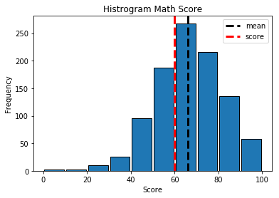

```python
# plotando os gráficos
plt.hist(df['math_score'], rwidth=0.9, edgecolor='k')
# Adicionando as legendas
plt.xlabel('Score')
plt.ylabel('Frequency')
# Adicionando o titulo
plt.title('Histrogram Math Score')
# Adicionando a linha de média
plt.axvline(mean_math, color = 'k', linestyle='dashed', linewidth=3)
# Adicionando a linha de nota minima
plt.axvline(60, color = 'r', linestyle='dashed', linewidth=3)
# Adicionando legendas
plt.legend(('mean','score'))
plt.show()
```

Criando um histrograma das notas de reading.

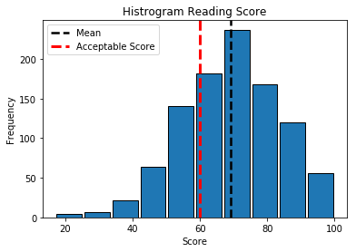

```python
plt.hist(df['reading_score'], rwidth=0.9, edgecolor='k')
plt.xlabel('Score')
plt.ylabel('Frequency')
plt.title('Histrogram Reading Score')
plt.axvline(mean_reading, color = 'k', linestyle='dashed', linewidth=2.5)
plt.axvline(60, color = 'r', linestyle='dashed', linewidth=3)
plt.legend(('Mean','Acceptable Score'))
plt.show()
```

Criando um histrograma das notas de writing.

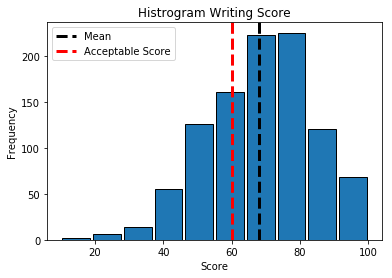

```python
plt.hist(df['writing_score'], rwidth=0.9, edgecolor='k')
plt.xlabel('Score')
plt.ylabel('Frequency')
plt.title('Histrogram Writing Score')
plt.axvline(mean_writing, color = 'k', linestyle='dashed', linewidth=3)
plt.axvline(60, color = 'r', linestyle='dashed', linewidth=3)
plt.legend(('Mean','Acceptable Score'))
plt.show()
```

Aviando os histogramas podemos concluir que:

- Em todas as matérias a maioria dos alunos tiraram notas acima do aceitável;
- Tivemos alunos com mais boas notas em writing;
- Tivemos alunos com mais notas ruins em math;

Contabilizando os alunos pelas notas (grades) e avaliando a quantidade em cada grupo.

```python
df.grade.value_counts()
```

```
E/F    285
C      261
D      256
B      146
A       52
Name: grade, dtype: int64
```

Avaliando graficamente.

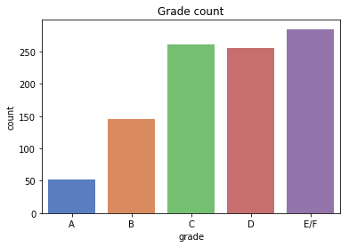

```python
sns.countplot(x="grade", data = df, order=['A','B','C','D','E/F'],  palette="muted")
plt.title('Grade count')
plt.show()
```

Podemos ver que a maioria dos alunos tiveram notas acima de E/F, o grupo com a maior quantidade de alunos é o E/F. Também podemos ver o número de alunos com conceito A é muito pequeno se comparado com os outros.

Vamos avaliar as caracterésticas dos alunos com conceito A.

Etnicidade dos alunos:

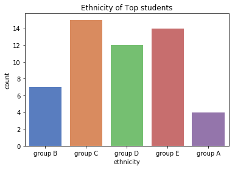

```python
sns.countplot(x='ethnicity', data = Top_students, palette="muted")
plt.title('Ethnicity of Top students')
plt.show()
```

Se os alunos fizeram ou não o exame preparátorio:

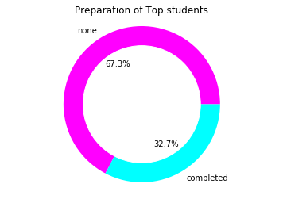

```python
plt.pie(Top_students.test_preparation_course.value_counts(), labels=['none','completed'], autopct='%1.1f%%', colors = ['magenta', 'cyan'])
my_circle=plt.Circle( (0,0), 0.75, color='white')
p=plt.gcf()
p.gca().add_artist(my_circle)
plt.axis('equal')
plt.title('Preparation of Top students')
plt.show()
```

A forma do financeamento dos estudos:

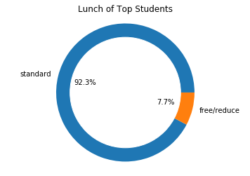

```python
plt.pie(Top_students.lunch.value_counts(), labels=['standard','free/reduce'], autopct='%1.1f%%')
my_circle=plt.Circle( (0,0), 0.8, color='white')
p=plt.gcf()
p.gca().add_artist(my_circle)
plt.axis('equal')
plt.title('Lunch of Top Students')
plt.show()
```

Nível de escolaridade dos pais dos estudantes.

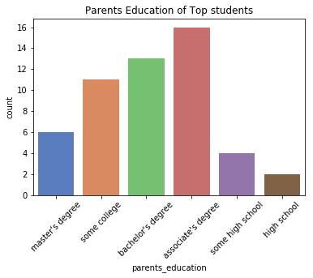

```python
p = sns.countplot(x='parents_education', data = Top_students, palette="muted")
plt.setp(p.get_xticklabels(), rotation=45)
plt.title('Parents Education of Top students')
plt.show()
```

Agora sobre os alunos que tiveram o conceito E/F, não aceitáveis:

Etnicidade dos alunos:

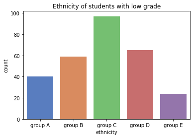

```python
sns.countplot(x='ethnicity', data = Fail_students, palette="muted")
plt.title('Ethnicity of students with low grade')
plt.show()
```

Se os alunos fizeram ou não um exame preparátorio:

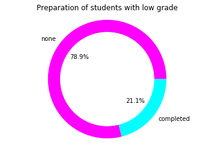

```python
plt.pie(Fail_students.test_preparation_course.value_counts(), labels=['none','completed'], autopct='%1.1f%%', labeldistance = 1.1,colors = ['magenta', 'cyan'])
my_circle=plt.Circle( (0,0), 0.79, color='white')
p=plt.gcf()
p.gca().add_artist(my_circle)
plt.axis('equal')
plt.title('Preparation of students with low grade')
plt.show()
```

A forma do financeamento dos estudos:

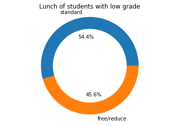

```python
plt.pie(Fail_students.lunch.value_counts(), labels=['standard','free/reduce'], autopct='%1.1f%%')
my_circle=plt.Circle( (0,0), 0.75, color='white')
p=plt.gcf()
p.gca().add_artist(my_circle)
plt.axis('equal')
plt.title('Lunch of students with low grade')
plt.show()
```

Nível de escolaridade dos pais dos estudantes.

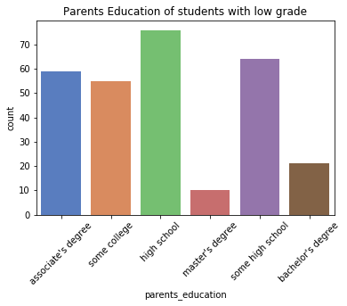

```python
p = sns.countplot(x='parents_education', data = Fail_students, palette="muted")
plt.setp(p.get_xticklabels(), rotation=45)
plt.title('Parents Education of students with low grade')
plt.show()
```

```python
df_f = df[df.gender == 'female']
df_m = df[df.gender == 'male']
```

```python
df_f.gender[df_f.gender == 'male'].count()
```

```
0
```

```python
df_m.gender[df_m.gender == 'female'].count()
```

```
0
```

A última análise será a de gêneros, qual teve os melhores desempenhos.

As notas em math:

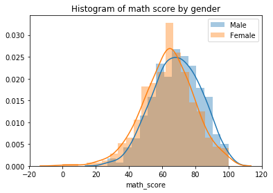

```python
sns.distplot(df_m['math_score'])
sns.distplot(df_f['math_score'])
plt.title('Histogram of math score by gender')
plt.legend(('Male','Female'))
plt.show()
```

As notas em reading:

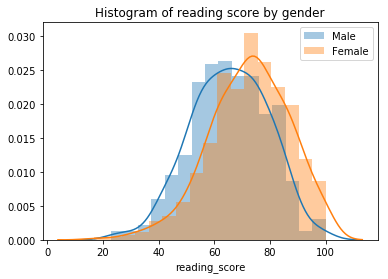

```python
sns.distplot(df_m['reading_score'])
sns.distplot(df_f['reading_score'])
plt.title('Histogram of reading score by gender')
plt.legend(('Male','Female'))
plt.show()
```

As notas em writing:

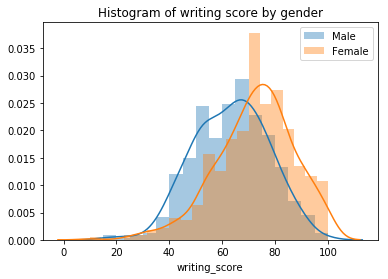

```python
sns.distplot(df_m['writing_score'])
sns.distplot(df_f['writing_score'])
plt.title('Histogram of writing score by gender')
plt.legend(('Male','Female'))
plt.show()
```

A comparação das médias dos alunos divididas por gênero:

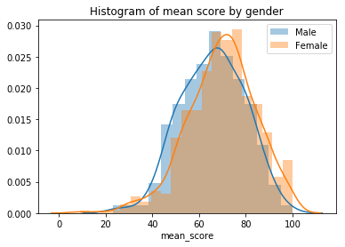

```python
sns.distplot(df_m['mean_score'])
sns.distplot(df_f['mean_score'])
plt.title('Histogram of mean score by gender')
plt.legend(('Male','Female'))
plt.show()
```

Com esses historgramas podemos concluir que:

- O desempenho no geral são similares entre mulheres e homens, mas as mulheres tem uma performace um pouco melhor;
- As mulheres tiveram um desempenho melhor em writing e reading;
- Os homens tiveram um desempenho melhor em math;

### Conclução

Convertendo as médias dos alunos em grades, notas por letra, organizamos os alunos em grupos de desempenho. Sendo os alunos com conceito A os de melhor desempenho e os de conceito E/F os de pior desempenho, segundo o sistema americano de grades. Embora tivessem a maioria dos alunos uma desempenho acima de E/F, o grupo de alunos E/F foi o que teve a maior quantidade de alunos, um resultado que tem a sua importância.